# Case Study #1

This data set represents thousands of loans made through the Lending Club platform, which is a platform that allows individuals to lend to other individuals. Of course, not all loans are created equal. Someone who is a essentially a sure bet to pay back a loan will have an easier time getting a loan with a low interest rate than someone who appears to be riskier. And for people who are very risky? They may not even get a loan offer, or they may not have accepted the loan offer due to a high interest rate. It is important to keep that last part in mind, since this data set only represents loans actually made, i.e. do not mistake this data for loan applications!

## Loading Libraries

```python
# importing the libraries

import numpy as np # linear algebra
import pandas as pd # data processing, CSV file I/O
import matplotlib.pyplot as plt
import seaborn as sns # for plotting

%matplotlib inline
```

## Reading the file

```python
df = pd.read_csv("loans_full_schema.csv")
```

## The First Rows

```python
df.shape
```

```
(10000, 55)
```

```python
df.head(10)
```

|  | emp_title | emp_length | state | homeownership | annual_income | verified_income | debt_to_income | annual_income_joint | verification_income_joint | debt_to_income_joint | ... | sub_grade | issue_month | loan_status | initial_listing_status | disbursement_method | balance | paid_total | paid_principal | paid_interest | paid_late_fees |
| --- | --- | --- | --- | --- | --- | --- | --- | --- | --- | --- | --- | --- | --- | --- | --- | --- | --- | --- | --- | --- | --- |
| 0 | global config engineer | 3.0 | NJ | MORTGAGE | 90000.0 | Verified | 18.01 | NaN | NaN | NaN | ... | C3 | Mar-2018 | Current | whole | Cash | 27015.86 | 1999.33 | 984.14 | 1015.19 | 0.0 |
| 1 | warehouse office clerk | 10.0 | HI | RENT | 40000.0 | Not Verified | 5.04 | NaN | NaN | NaN | ... | C1 | Feb-2018 | Current | whole | Cash | 4651.37 | 499.12 | 348.63 | 150.49 | 0.0 |
| 2 | assembly | 3.0 | WI | RENT | 40000.0 | Source Verified | 21.15 | NaN | NaN | NaN | ... | D1 | Feb-2018 | Current | fractional | Cash | 1824.63 | 281.80 | 175.37 | 106.43 | 0.0 |
| 3 | customer service | 1.0 | PA | RENT | 30000.0 | Not Verified | 10.16 | NaN | NaN | NaN | ... | A3 | Jan-2018 | Current | whole | Cash | 18853.26 | 3312.89 | 2746.74 | 566.15 | 0.0 |
| 4 | security supervisor | 10.0 | CA | RENT | 35000.0 | Verified | 57.96 | 57000.0 | Verified | 37.66 | ... | C3 | Mar-2018 | Current | whole | Cash | 21430.15 | 2324.65 | 1569.85 | 754.80 | 0.0 |
| 5 | NaN | NaN | KY | OWN | 34000.0 | Not Verified | 6.46 | NaN | NaN | NaN | ... | A3 | Jan-2018 | Current | whole | Cash | 4256.71 | 873.13 | 743.29 | 129.84 | 0.0 |
| 6 | hr | 10.0 | MI | MORTGAGE | 35000.0 | Source Verified | 23.66 | 155000.0 | Not Verified | 13.12 | ... | C2 | Jan-2018 | Current | whole | Cash | 22560.00 | 2730.51 | 1440.00 | 1290.51 | 0.0 |
| 7 | police | 10.0 | AZ | MORTGAGE | 110000.0 | Source Verified | 16.19 | NaN | NaN | NaN | ... | B5 | Jan-2018 | Current | whole | Cash | 19005.39 | 1765.84 | 994.61 | 771.23 | 0.0 |
| 8 | parts | 10.0 | NV | MORTGAGE | 65000.0 | Source Verified | 36.48 | NaN | NaN | NaN | ... | C2 | Feb-2018 | Current | whole | Cash | 18156.66 | 2703.22 | 1843.34 | 859.88 | 0.0 |
| 9 | 4th person | 3.0 | IL | RENT | 30000.0 | Not Verified | 18.91 | NaN | NaN | NaN | ... | A3 | Mar-2018 | Current | fractional | Cash | 6077.13 | 391.15 | 322.87 | 68.28 | 0.0 |

10 rows × 55 columns

## The Variables

We have 55 features, 54 variables and 1 response variable, the interest_rate

```python
df.info()
```

```
<class 'pandas.core.frame.DataFrame'>
RangeIndex: 10000 entries, 0 to 9999
Data columns (total 55 columns):
 #   Column                            Non-Null Count  Dtype
---  ------                            --------------  -----
 0   emp_title                         9167 non-null   object
 1   emp_length                        9183 non-null   float64
 2   state                             10000 non-null  object
 3   homeownership                     10000 non-null  object
 4   annual_income                     10000 non-null  float64
 5   verified_income                   10000 non-null  object
 6   debt_to_income                    9976 non-null   float64
 7   annual_income_joint               1495 non-null   float64
 8   verification_income_joint         1455 non-null   object
 9   debt_to_income_joint              1495 non-null   float64
```

[output cut: 47 more lines]

## Checking for missing values

Most of the variables do not have missing values, however, there are some that we need to taks actions

```python
df.isna().sum()
```

```
emp_title                            833
emp_length                           817
state                                  0
homeownership                          0
annual_income                          0
verified_income                        0
debt_to_income                        24
annual_income_joint                 8505
verification_income_joint           8545
debt_to_income_joint                8505
delinq_2y                              0
months_since_last_delinq            5658
earliest_credit_line                   0
inquiries_last_12m                     0
total_credit_lines                     0
open_credit_lines                      0
total_credit_limit                     0
total_credit_utilized                  0
num_collections_last_12m               0
num_historical_failed_to_pay           0
months_since_90d_late               7715
current_accounts_delinq                0
total_collection_amount_ever           0
current_installment_accounts           0
accounts_opened_24m                    0
months_since_last_credit_inquiry    1271
num_satisfactory_accounts              0
num_accounts_120d_past_due           318
num_accounts_30d_past_due              0
num_active_debit_accounts              0
total_debit_limit                      0
num_total_cc_accounts                  0
num_open_cc_accounts                   0
num_cc_carrying_balance                0
num_mort_accounts                      0
account_never_delinq_percent           0
tax_liens                              0
public_record_bankrupt                 0
loan_purpose                           0
application_type                       0
loan_amount                            0
term                                   0
interest_rate                          0
installment                            0
grade                                  0
sub_grade                              0
issue_month                            0
loan_status                            0
initial_listing_status                 0
disbursement_method                    0
balance                                0
paid_total                             0
paid_principal                         0
paid_interest                          0
paid_late_fees                         0
dtype: int64
```

## Dealing with Variables having missing values

I will gather here all the variables which has many missing values, I would like to fill those who have a few missing values with zero and those who are almost contains only these values I will toss them.

```python
variables_that_need_inspection = ['emp_length', 'debt_to_income', 'annual_income_joint', 'verification_income_joint',
                         'debt_to_income_joint', 'months_since_90d_late', 'months_since_last_delinq',
                         'months_since_last_credit_inquiry', 'num_accounts_120d_past_due']
```

```python
for elem in variables_that_need_inspection:
    print(df[elem].value_counts())
    print("\n")
```

```
10.0    3332
2.0      967
3.0      862
0.0      690
1.0      685
5.0      645
4.0      611
6.0      404
7.0      368
9.0      312
8.0      307
Name: emp_length, dtype: int64


0.00     28
16.11    14
13.20    12
19.42    12
20.66    12
         ..
23.90     1
0.32      1
8.82      1
35.22     1
45.26     1
Name: debt_to_income, Length: 3673, dtype: int64


90000.0     31
100000.0    30
140000.0    24
105000.0    21
80000.0     20
            ..
90200.0      1
101578.0     1
155918.0     1
74120.0      1
70598.0      1
Name: annual_income_joint, Length: 596, dtype: int64
```

[output cut: 65 more lines]

```
15.0    215
16.0    183
18.0    172
17.0    166
19.0    131
21.0    108
20.0    106
22.0    103
23.0     76
24.0     33
Name: months_since_last_credit_inquiry, dtype: int64


0.0    9682
Name: num_accounts_120d_past_due, dtype: int64
```

## Filling Missing values

I will ommit variables that have many missing values and for those who are a few, I will try fill some of them trying to understand what is missing.

```python
# emp_length is the Number of years in the job, rounded down.
# If longer than 10 years, then this is represented by the value 10.
# I believe that a mistake with the rounding process has happened and
# thus the missing values appeared
df['emp_length'].fillna(0, inplace=True)

# same concept and for the rest of the variables
# I believe that they need to replace the NA values with zero
# since the missing values they have, describe information that was ommitted
# to be entered and most probably based on the date described by these variables
# they describe lack of information when NA values occurs,
# so zero is most appropriate value to fill there.

df['debt_to_income'].fillna(0, inplace=True)
df['annual_income_joint'].fillna(0, inplace=True)
df['months_since_last_delinq'].fillna(0, inplace=True)
df['months_since_90d_late'].fillna(0, inplace=True)
df['months_since_last_credit_inquiry'].fillna(0, inplace=True)
df['num_accounts_120d_past_due'].fillna(0, inplace=True);
```

## Droping Columns with lots of missing values

Those variables below have so many missing values. More than 8000 values. It would be better to remove them from the dataset.

```python
df.drop(['annual_income_joint', 'verification_income_joint', 'debt_to_income_joint'], axis=1, inplace=True);
```

## Inspecting the numerical variables

Here we have some descriptive statistics for the numerical variables from the dataset

```python
df.describe()
```

|  | emp_length | annual_income | debt_to_income | delinq_2y | months_since_last_delinq | earliest_credit_line | inquiries_last_12m | total_credit_lines | open_credit_lines | total_credit_limit | ... | public_record_bankrupt | loan_amount | term | interest_rate | installment | balance | paid_total | paid_principal | paid_interest | paid_late_fees |
| --- | --- | --- | --- | --- | --- | --- | --- | --- | --- | --- | --- | --- | --- | --- | --- | --- | --- | --- | --- | --- | --- |
| count | 10000.000000 | 1.000000e+04 | 10000.000000 | 10000.00000 | 10000.000000 | 10000.00000 | 10000.00000 | 10000.000000 | 10000.00000 | 1.000000e+04 | ... | 10000.000000 | 10000.000000 | 10000.000000 | 10000.000000 | 10000.000000 | 10000.000000 | 10000.000000 | 10000.000000 | 10000.000000 | 10000.000000 |
| mean | 5.445800 | 7.922215e+04 | 19.261852 | 0.21600 | 15.961500 | 2001.29000 | 1.95820 | 22.679600 | 11.40440 | 1.836062e+05 | ... | 0.123800 | 16361.922500 | 43.272000 | 12.427524 | 476.205323 | 14458.916610 | 2494.234773 | 1894.448466 | 599.666781 | 0.119516 |
| std | 3.903279 | 6.473429e+04 | 15.016585 | 0.68366 | 23.135028 | 7.79551 | 2.38013 | 11.885439 | 5.86828 | 1.876327e+05 | ... | 0.337172 | 10301.956759 | 11.029877 | 5.001105 | 294.851627 | 9964.561865 | 3958.230365 | 3884.407175 | 517.328062 | 1.813468 |
| min | 0.000000 | 0.000000e+00 | 0.000000 | 0.00000 | 0.000000 | 1963.00000 | 0.00000 | 2.000000 | 0.00000 | 0.000000e+00 | ... | 0.000000 | 1000.000000 | 36.000000 | 5.310000 | 30.750000 | 0.000000 | 0.000000 | 0.000000 | 0.000000 | 0.000000 |
| 25% | 2.000000 | 4.500000e+04 | 10.997500 | 0.00000 | 0.000000 | 1997.00000 | 0.00000 | 14.000000 | 7.00000 | 5.159375e+04 | ... | 0.000000 | 8000.000000 | 36.000000 | 9.430000 | 256.040000 | 6679.065000 | 928.700000 | 587.100000 | 221.757500 | 0.000000 |
| 50% | 5.000000 | 6.500000e+04 | 17.530000 | 0.00000 | 0.000000 | 2003.00000 | 1.00000 | 21.000000 | 10.00000 | 1.146670e+05 | ... | 0.000000 | 14500.000000 | 36.000000 | 11.980000 | 398.420000 | 12379.495000 | 1563.300000 | 984.990000 | 446.140000 | 0.000000 |
| 75% | 10.000000 | 9.500000e+04 | 24.990000 | 0.00000 | 29.000000 | 2006.00000 | 3.00000 | 29.000000 | 14.00000 | 2.675500e+05 | ... | 0.000000 | 24000.000000 | 60.000000 | 15.050000 | 644.690000 | 20690.182500 | 2616.005000 | 1694.555000 | 825.420000 | 0.000000 |
| max | 10.000000 | 2.300000e+06 | 469.090000 | 13.00000 | 118.000000 | 2015.00000 | 29.00000 | 87.000000 | 51.00000 | 3.386034e+06 | ... | 3.000000 | 40000.000000 | 60.000000 | 30.940000 | 1566.590000 | 40000.000000 | 41630.443684 | 40000.000000 | 4216.440000 | 52.980000 |

8 rows × 40 columns

# Exploring the data

There are many features, 54 features and 1 response variable. I would like to explore with some features that picked my interest. I will start with the response variable, seems the interest_rate has right skewed distribution.

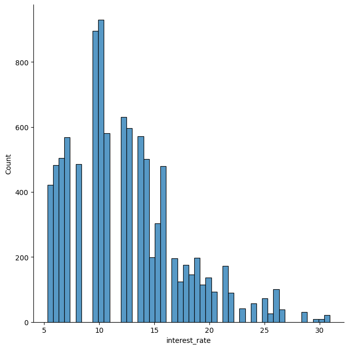

```python
sns.displot(data=df, x="interest_rate", height=7, aspect=1)
```

## Home owners variable

One variable that caught my attention is this one, Home Owners, I want to see, from those who accepted and got a loan, what type of homeowners they are?

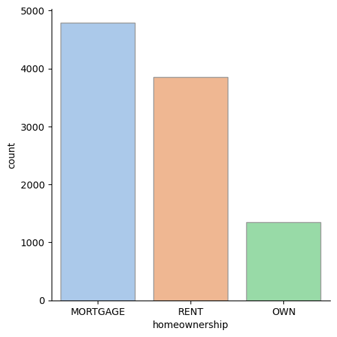

```python
sns.catplot(data=df, x="homeownership", kind="count", palette="pastel", edgecolor=".6")
```

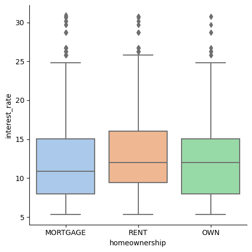

```python
sns.catplot(data=df, x="homeownership", y="interest_rate", kind="box", palette="pastel")
```

Lets see the relationship between the response variabla and the types of home owners. Seems that the distribution of the interest rates between homeowners remains the same.

## State

I would like to explore the number of loans by state of origin. California, Florida, Texas and New York have the most of the loans made in the loan club.

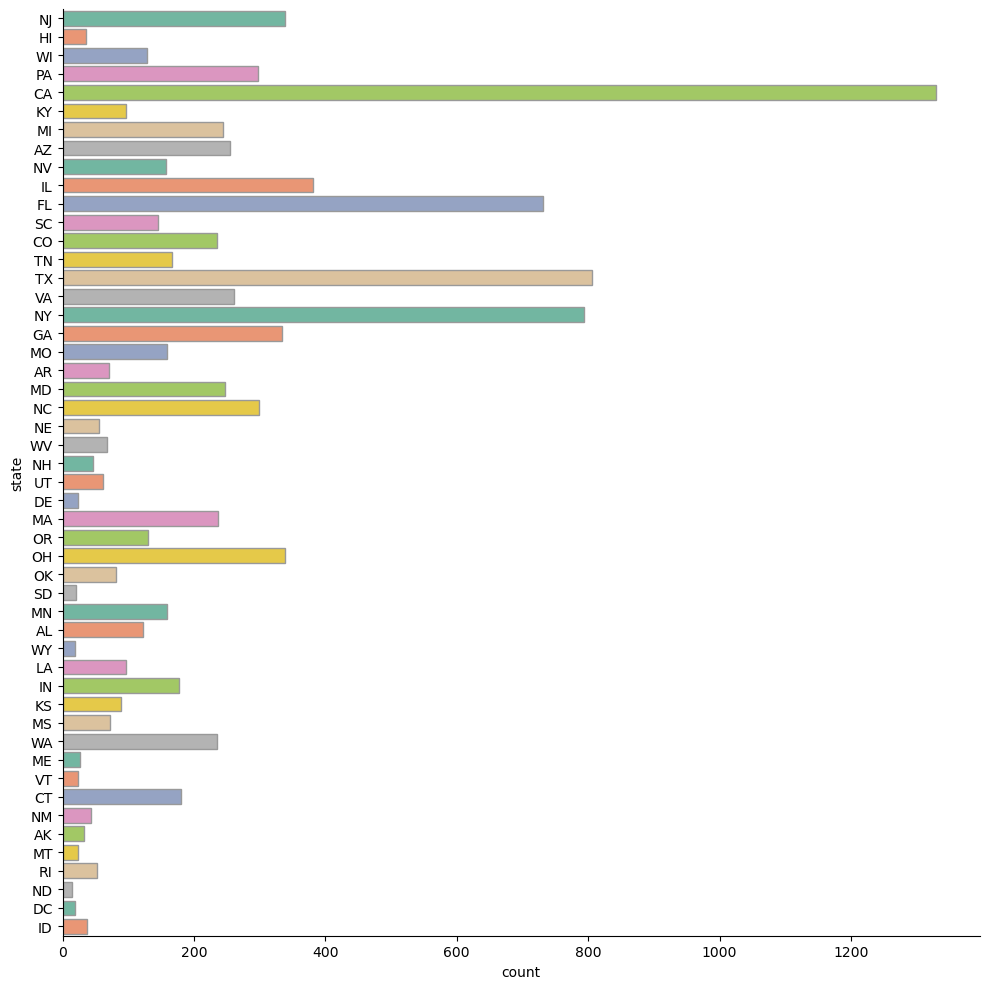

```python
p = sns.catplot(data=df, y="state", kind="count", palette="Set2", edgecolor=".6", height=10, aspect=1)
```

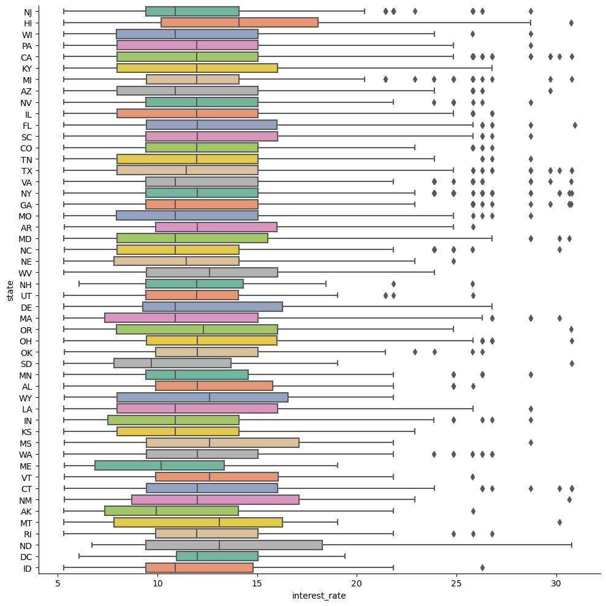

```python
sns.catplot(data=df, x="interest_rate", y="state", kind="box",
            palette="Set2",
           height=10,
    aspect=1)
```

# Annual income

Another numerical variable I would like to inspect is the annual income of the applicants who took a loan. The distribution is very narrow and highly right skewed, which means that most of the annual incomes range between a very specific area, however there are annual salaries that pushes the distribution not to be symmetrical but right skewed.

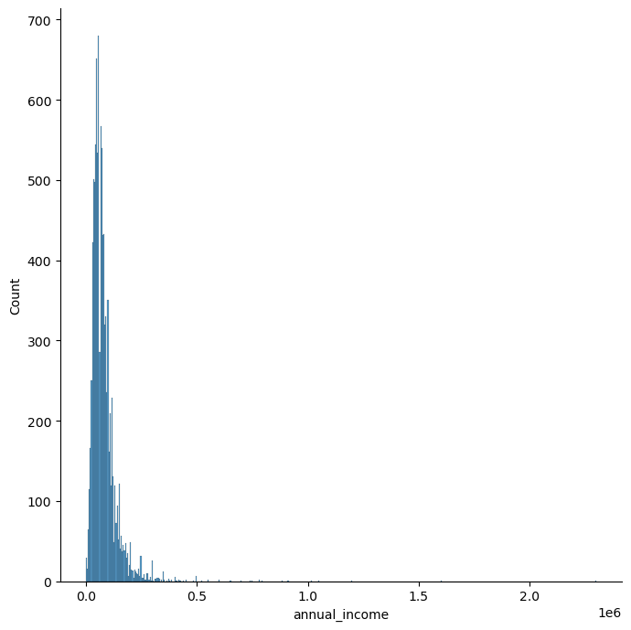

```python
sns.displot(data=df, x="annual_income", height=7, aspect=1)
```

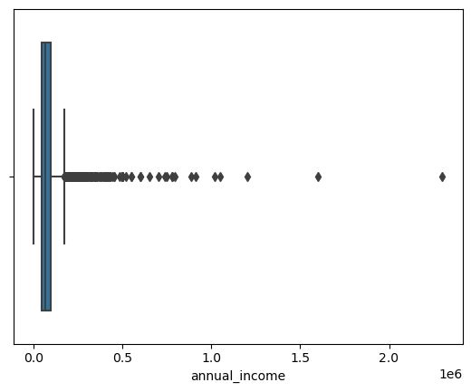

```python
sns.boxplot(data=df, x="annual_income")
plt.show()
```

I would like to see the relationship between annual income and interest_rate. It seems that there is a negative relationship between the 2. As long as the interest_rate increases the annual income decreases.

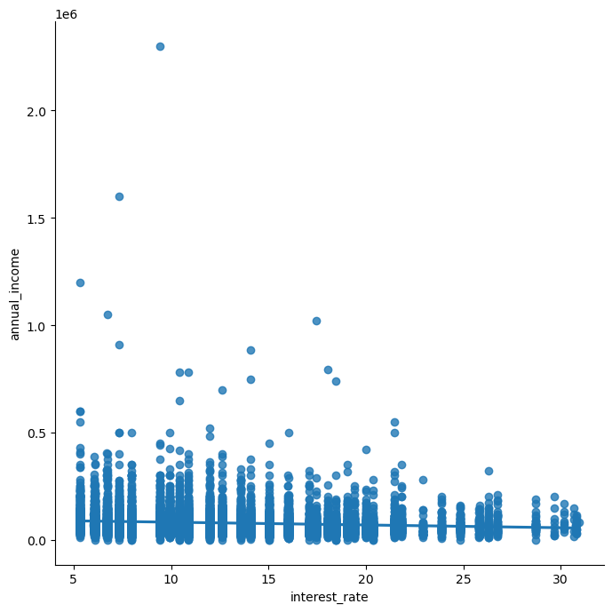

```python
sns.lmplot(data=df, x="interest_rate", y="annual_income", height=7,
    aspect=1)
```

## Verified Income

Verified Income is the type of verification of the applicant's income. Most of the applicants' incomes are verified but it is important to be noted that there is a good portion of those who didn't verify the source of their income and received a loan from the loan club.

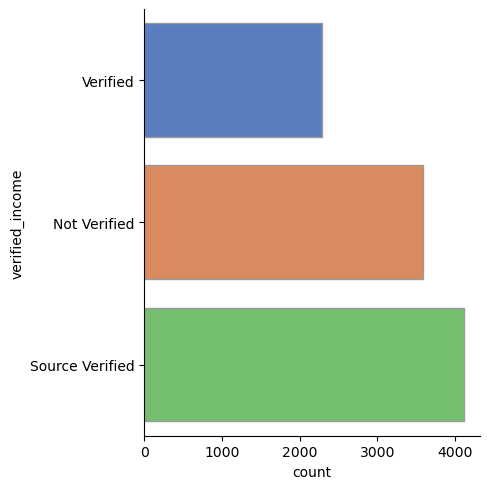

```python
p = sns.catplot(data=df, y="verified_income", kind="count",
    palette="muted", edgecolor=".6", height=5, aspect=1)
```

Furthermore, the distribution of the interest rate between the different groups of verified annual income is very different.

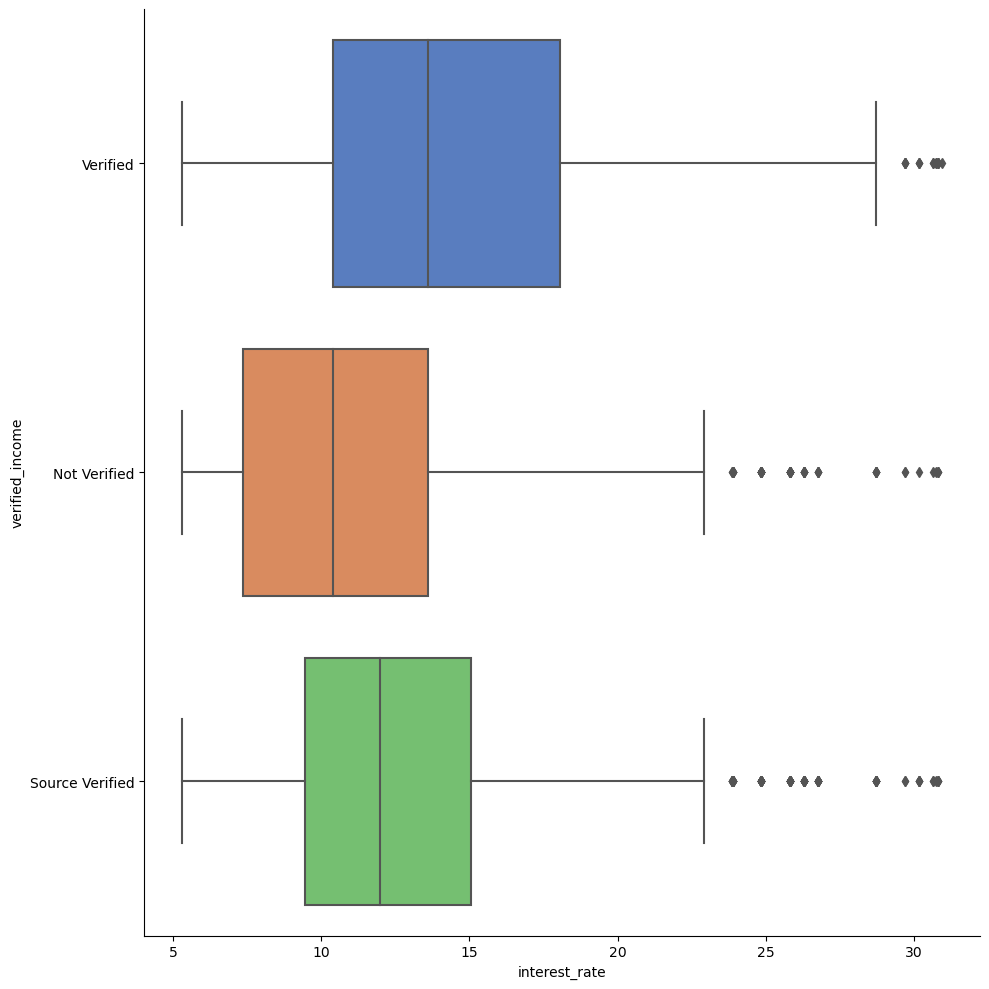

```python
sns.catplot(data=df, x="interest_rate", y="verified_income", kind="box", palette="muted", height=10, aspect=1)
```

## Loan Purpose

Most of the loans are given with the purpose of debt_consolidation and to cover expenses from credit_cards.

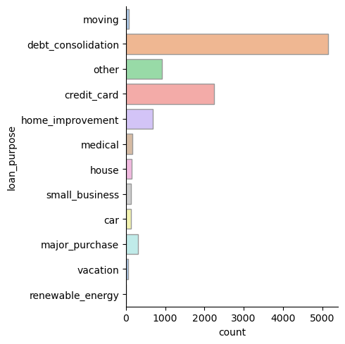

```python
p = sns.catplot(
    data=df, y="loan_purpose", kind="count",
    palette="pastel", edgecolor=".6",
height=5,
    aspect=1)
```

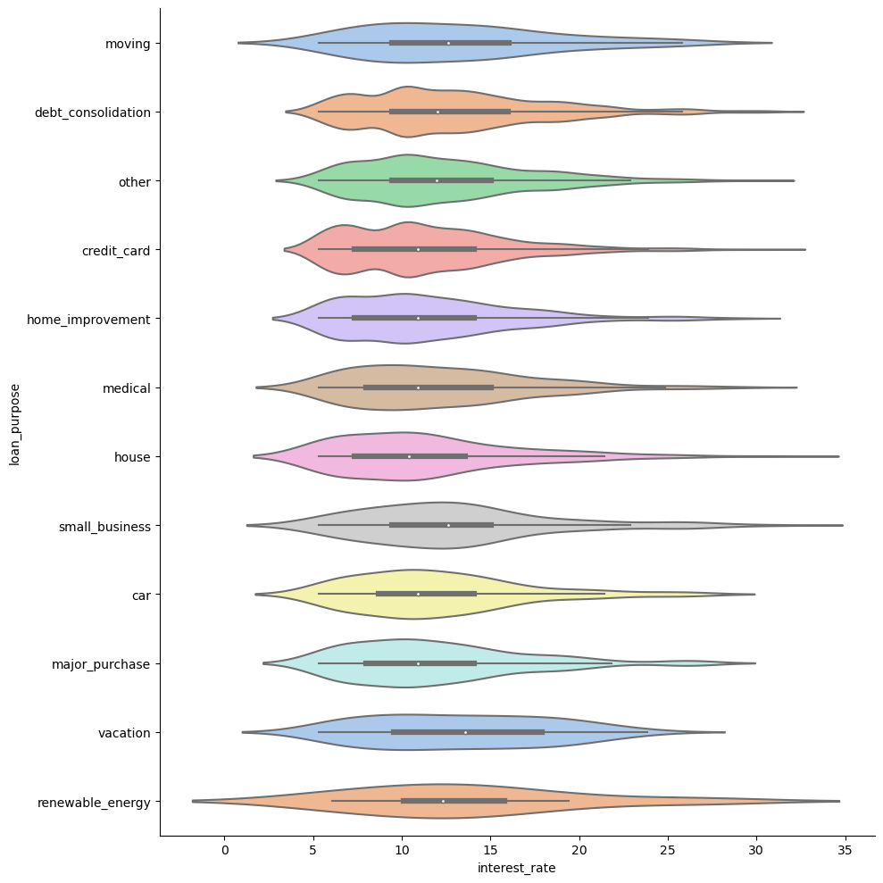

```python
sns.catplot(data=df, x="interest_rate", y="loan_purpose", kind="violin", palette="pastel", height=10,aspect=1)
```

## Loan Status

The majority of the loans are not paid yet and a very small portion of them are fully paid.

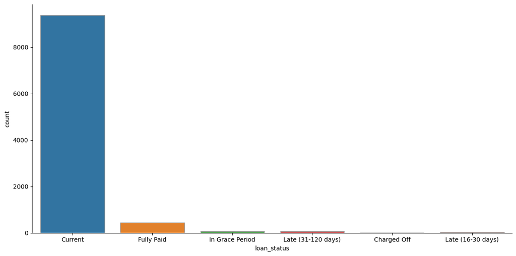

```python
p = sns.catplot(data=df, x="loan_status", kind="count", palette="tab10", edgecolor=".6", height=6, aspect=2)
```

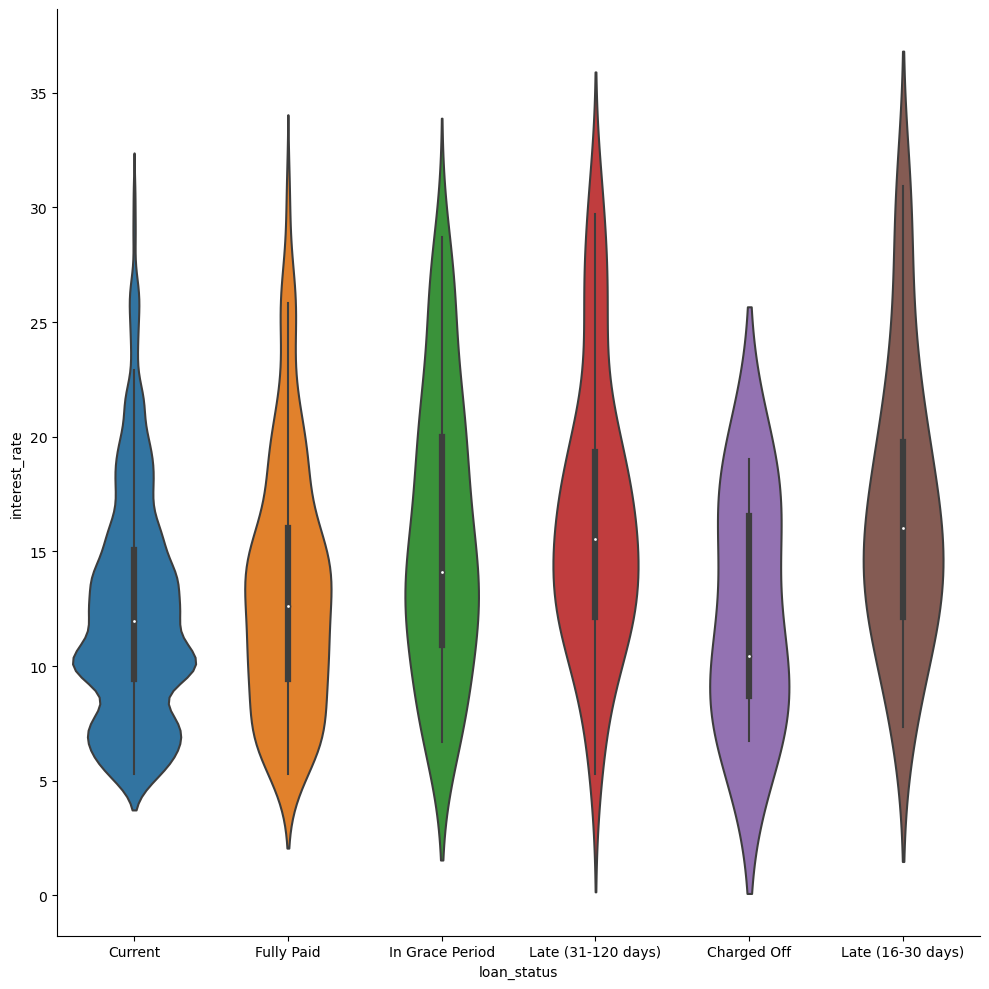

```python
sns.catplot(data=df, y="interest_rate", x="loan_status", kind="violin", palette="tab10",
           height=10, aspect=1)
```

## Debt_to_income

Debt-to-income ratio. Another numerical variable which is highly right skewed.

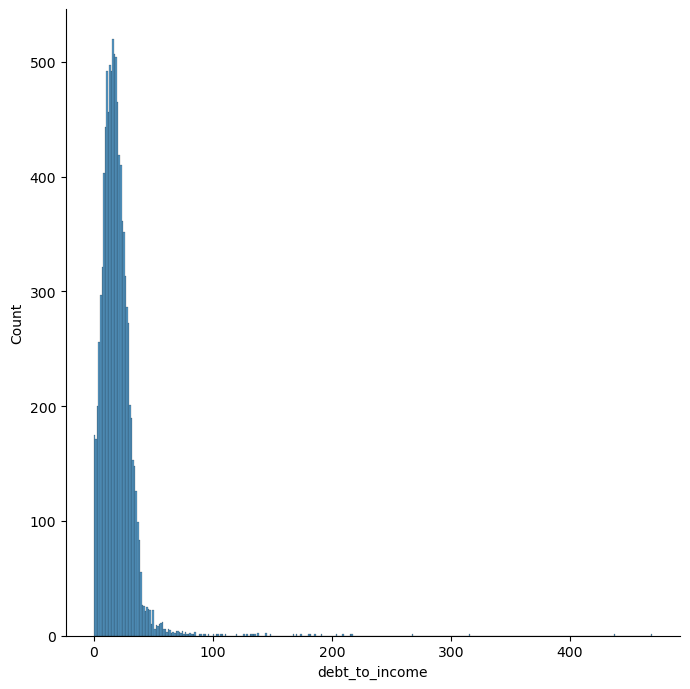

```python
sns.displot(data=df, x="debt_to_income", height=7, aspect=1)
```

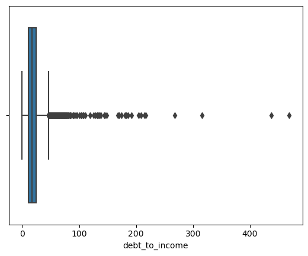

```python
sns.boxplot(data=df, x="debt_to_income")
```

Seems that there is a positive relationship between debt_to_income and interest_rate.

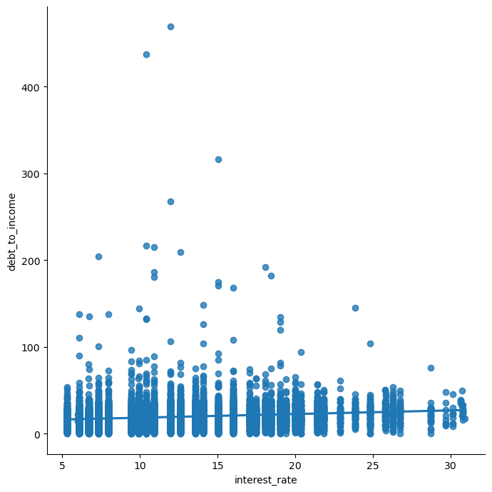

```python
sns.lmplot(data=df, x="interest_rate", y="debt_to_income", height=7, aspect=1)
```

## Correlations between Response variable and the rest of Numerical variables

```python
df.select_dtypes(include=[np.number]).corr()['interest_rate'].sort_values(ascending = False)[0:5]
```

```
interest_rate         1.000000
paid_interest         0.514508
term                  0.358664
debt_to_income        0.139813
inquiries_last_12m    0.131193
Name: interest_rate, dtype: float64
```

```python
df.select_dtypes(include=[np.number]).corr()['interest_rate'].sort_values(ascending = False)[-5:-1]
```

```
account_never_delinq_percent   -0.124702
total_credit_limit             -0.130497
num_mort_accounts              -0.138351
total_debit_limit              -0.254225
Name: interest_rate, dtype: float64
```

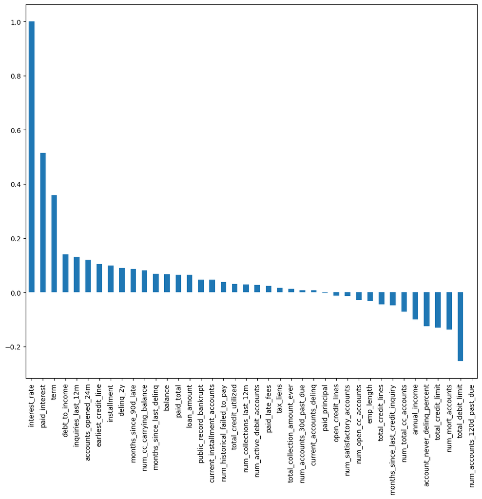

```python
df.select_dtypes(include=[np.number]).corr()['interest_rate'].sort_values(ascending = False).plot(kind='bar', figsize=(12, 10))
```

# Machine Learning Models

## Preparing feature set before building predictive models

Since we have many categorical variables, we need to encode them in order to be suitable for building models later on. Thus I used the one-hot-encoding technique to turn all the categorical variables into numerical encoded variables.

```python
df.drop(['emp_title'], axis=1) # droping the name of the Job title

df_dummies = pd.get_dummies(df.select_dtypes(exclude=[np.number]))
df_new = pd.concat([df.select_dtypes(include=[np.number]), df_dummies], axis=1)
```

Seperating the features X and the response variable y

```python
y = df_new["interest_rate"] # response variable
X = df_new.drop(['interest_rate'], axis=1, inplace=False)
```

## KNeighborsRegressor model

I will use the Knn model (K-Nearest neighbors) for regression. The target is predicted by local interpolation of the targets associated of the nearest neighbors in the training set.

I will split the train set X, and the validation set y into 10 folds and using cross validation will evaluate the performance of the model with the MAE metric (Mean absolute error score).

https://scikit-learn.org/stable/modules/generated/sklearn.neighbors.KNeighborsRegressor.html

```python
from sklearn.neighbors import KNeighborsRegressor
from sklearn.model_selection import cross_val_score


KNeighborsRegressor_clc = KNeighborsRegressor(n_neighbors=4)
KNeighborsRegressor_scores = cross_val_score(KNeighborsRegressor_clc, X, y, cv=10, scoring='neg_mean_absolute_error', n_jobs=-1, verbose=1)
```

```
[Parallel(n_jobs=-1)]: Using backend LokyBackend with 4 concurrent workers.
[Parallel(n_jobs=-1)]: Done  10 out of  10 | elapsed:   35.6s finished
```

```python
print("Mean score of %0.2f with a standard deviation of %0.2f" % ((-1)*KNeighborsRegressor_scores.mean(),
                                                                  KNeighborsRegressor_scores.std()))
```

```
Mean score of 3.88 with a standard deviation of 0.10
```

## Random Forest model

I will use the Random Forest model for regression. Random Forest is an ensemble learning method for classification and regression and it is based on the bagging of the training set.

I will again split the train set X, and the validation set y into 10 folds and using cross validation will evaluate the performance of the model with the MAE metric (Mean absolute error score).

```python
from sklearn.ensemble import RandomForestRegressor
from sklearn.model_selection import cross_val_score


random_forest_clc = RandomForestRegressor(random_state=1, max_depth=6, n_estimators=50, n_jobs=-1)
random_forest_scores = cross_val_score(random_forest_clc, X, y, cv=10, scoring='neg_mean_absolute_error', n_jobs=-1, verbose=1)
```

```
[Parallel(n_jobs=-1)]: Using backend LokyBackend with 4 concurrent workers.
[Parallel(n_jobs=-1)]: Done  10 out of  10 | elapsed:  2.5min finished
```

```python
print("Mean score of %0.2f with a standard deviation of %0.2f" % ((-1)*random_forest_scores.mean(), random_forest_scores.std()))
```

```
Mean score of 0.12 with a standard deviation of 0.01
```

Random forest model is slower than Knn, it took 2.5 minutes to evaluate all folds. Mean MAE score is 0.12 and std of scores are 0.01.

# Conclusion and future suggestions

Random Forest shows better accuracy than kNN model. It had less error and the std. of errors were insignificant small.

In order to improve my models more I would like to reduce the amount of variables used for training. Maybe using the correlation table to choose those who correlation more with the interest_rate.

Moreover, I would like to find out the most important features after building training our models. Which features are these that have more impact to make predictions or they have a larger effect on the model that is being used to predict a certain variable.

Finally I would like to perform a tuning to my models to find better optimal parameters for the models to reduce the error of prediction even more.